# Southeast Florida Socio-Economic Data Trends

Amar Sarvepalli

January 30, 2017

### Check Socio-Economic Data Trend

This chapter fouces on checking and reporting of socio-demograhic and employment data from 2010, 2015 and 2040.

#### 1. Data Processing

The regional planning models contains valuable data that can be used beyond travel demand forecasting needs. The forecasted landuse and employment are one of the most useful information for general use. However, in SERPM 7.0 this data exists in a few different places with similar names but with significant variations.

SERPM is an acitivity based model and is one of the most sophisticated models where cooridanted daily activity pattern is the epic center of its design, meaning it is designed to simulate varrying travel patterns of each individuals of the housheolds by taking their household socio-demographics and personal profiles into account. This model consists of various sequential sub-modules and use variants of the same datasets as required by each sub-models. For this reason the disaagregate household and population variables such as: zero-car autos, zero-worker households, low-income hosueholds, population under age < 16 and over 65 plus can only be found in the output files. However, the zonal level housheold, population variables are user inputs and can be obtained from the inputs location. Although employment is also a user input file, this can only be found under inputs to ctramp folder, which is at a different location than landuse input files.

As it can be seen, extracting useful general purpose information from the model is different and needs thorough understanding of the SERPM model. To address this issue, R-Script were developed to extract the model data.

The SERPM model input and output files are pre-proccessed to produce model data file (*year_model_data.csv*) that are referred in this document. These files are generated by processing the following files:

1. input/ctramp/hhFile.csv : synthetic households output from PopSyn-3
2. input/ctramp/maz_data.csv : employment data user input
3. output/ctramp/householdData_1.csv : cooridnated daily activity pattern (cdap) household data from ctramp
   4. output/ctramp/personData_1.csv : cooridnated daily activity pattern (cdap) person data from ctramp

*Note: Script **GetPopHH.R** is run on SERPM model results for 2010, 2015 and 2040 to extract **year_model_data.csv** files processes*

The first two are outputs from synthetic population generator. The household, population variables in the **ctramp/maz_data.csv** file doesn’t necessarily agree with **PopSyn-3/maz_data.csv**, although they correspond to the hosuehold and popualtion variables. This difference is due to balancing priorities used in PopSyn-3, where some of the variables are given a higher priority to match to control totals (usually at TAZ level). In cases where zonal data is being analyzed, it is better to use household and population data from input to PopSyn-3 instead of ctramp inputs.

```r
  # directory
  projDir <-"/Volumes/C/projects/SERPM_Compare/extract_SERPM_SEData"

  # data directory and files
  model_dir <- "model_data"
  se_data_files <- c("2010_model_data.csv", "2015_model_data.csv", "2040_model_data.csv")

  # Taz to county lookup file (use shape file instead)
  taz_county_file <- "taz_county.csv"

  # District file to tabluate data for Flalger distritcs
  taz_district_file <- "SERPM_TAZ_AirSage_Dist.csv"
  segments_1 <- c(19:22,27,28,30)                # Flagler: 1st St to NW 27th Ave
  segments_2 <- c(25,31,33:35, 15)               # Flagler: NW 27th Ave to SR 826 Exp
  segments_3 <- c(36:40,601,602,591,592,56,48)   # SW 8th St: SR 826 Exp to SW 147th Ave
  Study_districts <- c(segments_1,segments_2,segments_3)

  # Write csv outputs
  write.csv.outputs <- FALSE
```

Table below shows the household, dempgraphics summary by county

| var | 2010 | 2015 | 2040 |
| --- | --- | --- | --- |
| AGE0TO17 | 543463.08 | 566532.62 | 688720.6 |
| AGE18TO24 | 248625.57 | 266056.79 | 341708.9 |
| AGE25TO34 | 341143.58 | 360428.29 | 454340.2 |
| AGE35TO49 | 576651.18 | 606876.67 | 737961.3 |
| AGE50TO64 | 444111.28 | 463412.18 | 600906.5 |
| AGE65TO79 | 254243.09 | 270448.27 | 334011.6 |
| AGE80PLUS | 107155.22 | 110387.18 | 149432.8 |
| emp | 1125068.00 | 1210746.00 | 1636614.0 |
| hh | 908040.00 | 958536.00 | 1215286.0 |
| INCOME_100K | 151935.74 | 157479.22 | 193939.4 |
| INCOME_100KPLUS | 91907.13 | 99789.51 | 120420.1 |
| INCOME_25K | 263952.04 | 282237.44 | 373593.7 |
| INCOME_50K | 146274.77 | 153250.02 | 197582.9 |
| INCOME_75K | 241239.31 | 254122.81 | 318433.0 |
| pop | 2515905.00 | 2644830.00 | 3307549.0 |
| zero_auto | 11716.00 | 13429.00 | 20977.0 |

| var | 2010 | 2015 | 2040 |
| --- | --- | --- | --- |
| AGE0TO17 | 66237.69 | 70260.84 | 92998.88 |
| AGE18TO24 | 35196.51 | 38935.21 | 52452.34 |
| AGE25TO34 | 52459.50 | 58698.06 | 82926.17 |
| AGE35TO49 | 88997.01 | 93779.57 | 123313.40 |
| AGE50TO64 | 65080.84 | 68420.88 | 91665.76 |
| AGE65TO79 | 45206.27 | 47715.89 | 62288.38 |
| AGE80PLUS | 21055.18 | 21267.55 | 31188.07 |
| emp | 224238.00 | 238417.00 | 308902.00 |
| hh | 139748.00 | 151254.00 | 209478.00 |
| INCOME_100K | 22668.70 | 23546.74 | 30761.74 |
| INCOME_100KPLUS | 10863.20 | 12408.64 | 17351.61 |
| INCOME_25K | 48995.26 | 54373.22 | 76948.27 |
| INCOME_50K | 15878.41 | 17820.90 | 28773.50 |
| INCOME_75K | 39643.43 | 41430.51 | 54019.86 |
| pop | 374316.00 | 399262.00 | 536891.00 |
| zero_auto | 2702.00 | 3235.00 | 6152.00 |

Plot of demographic trends

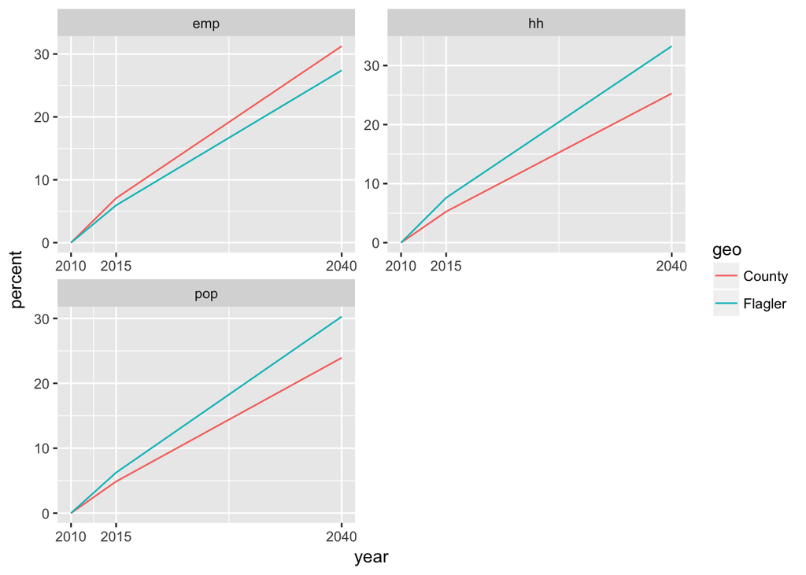

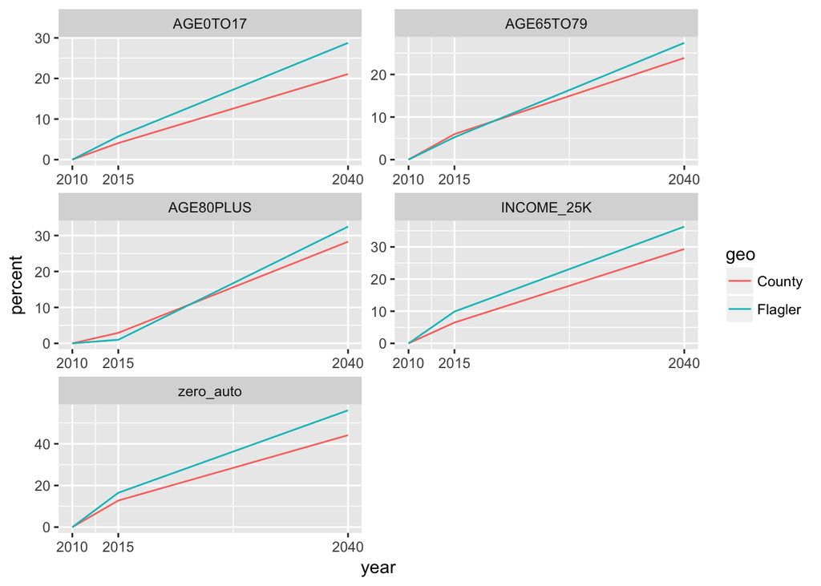